# trupol India data

Erica Yoon

Jan 10, 2016

```r
# trupol_ana_preprocess

rm(list=ls())
library(ggplot2)
library(plyr)
library(dplyr)
library(tidyr)
source("/Users/ericang/Documents/Research/trupol/data/version 1/helper/useful.R")
d <- read.csv("/Users/ericang/Documents/Research/trupol/data/version 2/india/trupol_coding.csv")
# log <- read.csv("/Users/ericang/Documents/Research/Politeness/trupol_git/data_analysis/info/trupol_subj.csv")
#
# # join with subj log
# d <- join(d, log)

# select key vars
d <- d %>%
  select(subid, site, age, cond, trial1_2_eval, trial1_2_play, trial3_4_play, trial3_4_eval, trial1_nice, trial2_nice, trial3_nice, trial4_nice, trial1_mean, trial2_mean, trial3_mean, trial4_mean, trial1_truth, trial2_truth, trial3_truth, trial4_truth)

# # categorize age
# d$Age <- as.numeric(as.character(d$Age))
# d <- cbind(d, age_cat = cut(d$Age, breaks=c(3, 5, 7, 9)))
# levels(d$age_cat) <- c("3-4", "5-6", "7-8")
# summary(d$age_cat)

# reshape data
d <- d %>%
  gather("q", "answer", 5:20)
# add columns to categorize vars
d1 <- d %>%
  mutate(polite = factor(substring(q, 1, 8),
                         levels = c("trial1_2", "trial3_4",
                                    "trial1_n", "trial2_n", "trial3_n", "trial4_n",
                                    "trial1_m", "trial2_m", "trial3_m", "trial4_m",
                                    "trial1_t", "trial2_t", "trial3_t", "trial4_t"),
                         labels = c("NA", "NA",
                                    "honest", "polite", "polite", "honest",
                                    "honest", "polite", "polite", "honest",
                                    "honest", "polite", "polite", "honest")),
         q_kind = factor(substring(q, 8, 10),
                         levels = c("2_e", "2_p", "4_p", "4_e",
                                    "nic", "mea", "tru"),
                         labels = c("eval", "play", "play", "eval",
                                    "niceness", "meanness", "truth-telling")))
d1$age <- as.factor(as.character(d1$age))
d1$polite <- as.factor(as.character(d1$polite))
d1$q_kind <- as.factor(as.character(d1$q_kind))
d1$answer <- as.factor(as.character(d1$answer))
levels(d1$answer) <- c("1", "1", "0", "0", "0", "1") # honest coded as '1'
d1$answer <- as.numeric(as.character(d1$answer))
```

# correct responses on eval and play questions

play: “who do you want to play with?” eval: “whose snack do you think is tastier (given the same utterance)?”

```r
# plot: eval and play
mss <- d1 %>%
  filter(q_kind == "play" | q_kind == "eval") %>%
  group_by(age, cond, q_kind, subid) %>%
  summarize(
    answer = mean(answer, na.rm=TRUE)
  )
ms <- aggregate(answer ~ age + cond + q_kind, mss, mean)
ms$cih <- aggregate(answer ~ age + cond + q_kind, mss, ci.high)$answer
ms$cil <- aggregate(answer ~ age + cond + q_kind, mss, ci.low)$answer
```

## barplot:

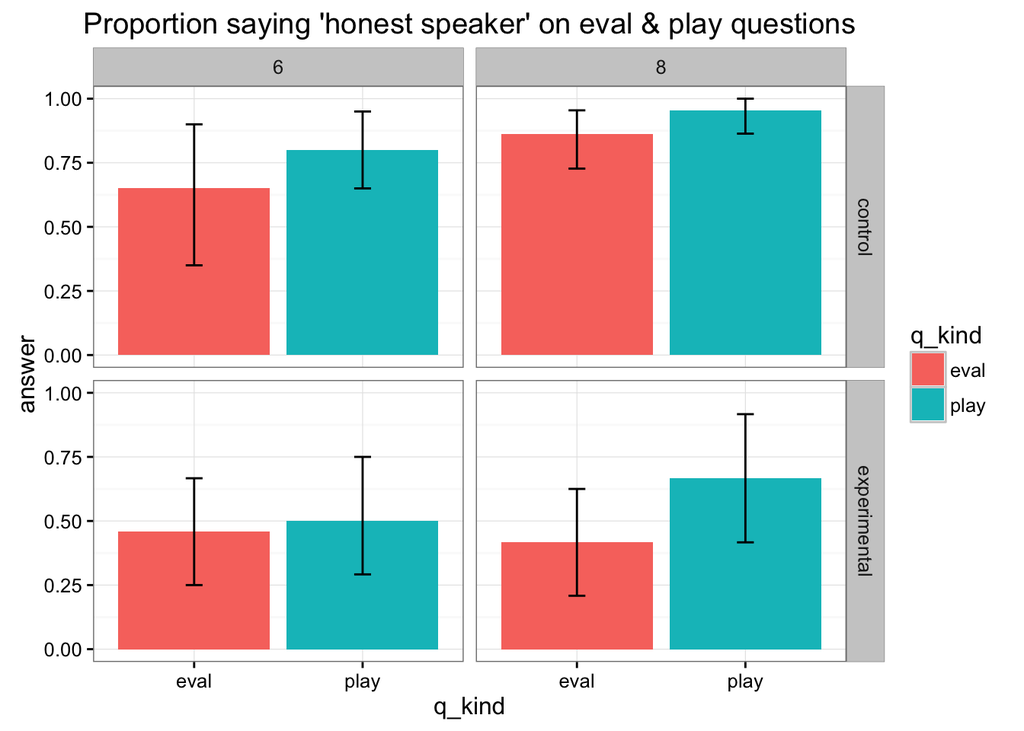

```r
levels(ms$cond) <- c("control", "experimental")

p <- ggplot(ms, aes(x=q_kind, y=answer, fill=q_kind))
p +
  geom_bar(position = "dodge", stat = "identity") +
  geom_errorbar(aes(ymin=answer-cil,ymax=answer+cih,width=.1)) +
  facet_grid(cond~age) +
  ggtitle("Proportion saying 'honest speaker' on eval & play questions")
```

# nice/mean/truth-telling rating

```r
# plot: niceness
mss <- d1 %>%
  filter(q_kind == "niceness" | q_kind == "meanness" | q_kind == "truth-telling") %>%
  group_by(age, cond, polite, q_kind, subid) %>%
  summarize(
    answer = mean(answer, na.rm=TRUE)
  )
ms <- aggregate(answer ~ age + cond + polite + q_kind, mss, mean)
ms$cih <- aggregate(answer ~ age + cond + polite + q_kind, mss, ci.high)$answer
ms$cil <- aggregate(answer ~ age + cond + polite + q_kind, mss, ci.low)$answer
```

## barplot

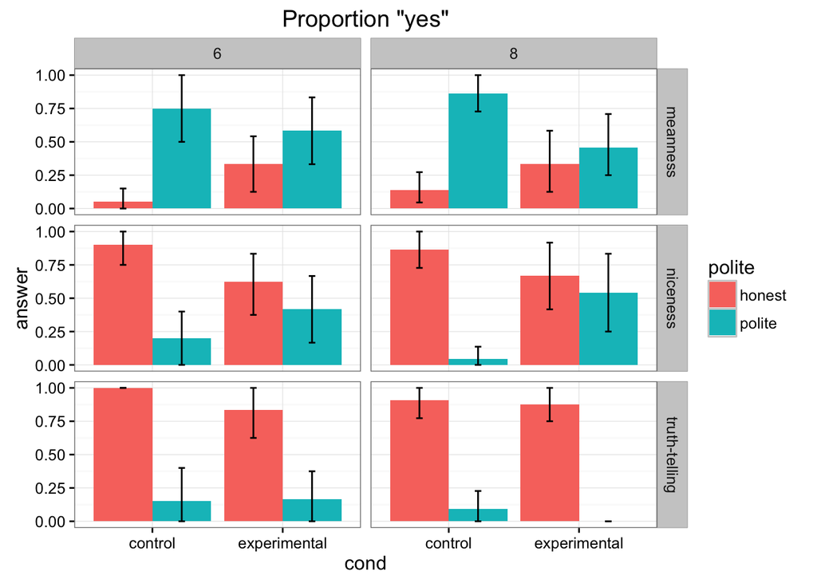

```r
levels(ms$cond) <- c("control", "experimental")
p <- ggplot(subset(ms, answer!="NA"),
            aes(x=cond, y=answer, fill=polite))
p +
  geom_bar(position=position_dodge(), stat = "identity") +
  facet_grid(q_kind~age) +
  geom_errorbar(position=position_dodge(.9), aes(ymin=answer-cil,ymax=answer+cih,width=.1)) +
  ggtitle("Proportion \"yes\"")
```

Both age groups correctly said the honest speaker was telling the truth, whereas the dishonest speaker was not.

8-year-olds said dishonest speaker is less mean and nicer when he/she is being polite compared to when he/she is lying with no reason, whereas 6-year-olds did not differentiate between the two situations.

For both age groups, but especially 6-year-olds interestingly, there was numerical difference which suggests the honest speaker was considered to be more mean and less nice when he/she was being impolite.